# Exploring The effects Of An online asynchronous mindfulness meditation intervention with nursing students On Stress, mood, And Cognition: A descriptive study - ScienceDirect

## [Nurse Education Today](https://www.sciencedirect.com/journal/nurse-education-today)

[Volume 39](https://www.sciencedirect.com/journal/nurse-education-today/vol/39/suppl/C), April 2016, Pages 163-169

# Exploring The effects Of An online asynchronous mindfulness meditation intervention with nursing students On Stress, mood, And Cognition: A descriptive study☆

Full text access

## Highlights

- •

  Stress, mood, and cognition were explored with nurses returning to school.
- •

  Asynchronous online mindfulness intervention developed and provided using the university's learning management system.
- •

  Faculty awareness that students may experience changes in stress levels, mood and cognition that can impact academic success.
- •

  Mindfulness meditation can be one method to address stress, mood, and cognitive changes in distance nursing students.

## Summary

### Background

Nurses returning to school while working, raising families, and maintaining other roles, can experience stress, mood changes and cognition disturbance that negatively impact their academic success.

### Objectives

To explore the effect of an online [mindfulness meditation](https://www.sciencedirect.com/topics/psychology/mindfulness-meditation) intervention with distance nursing students on stress, mood and cognition.

### Design

A 24 week descriptive study.

### Settings

An 8 week online intervention was offered to all undergraduate and [graduate nursing students](https://www.sciencedirect.com/topics/nursing-and-health-professions/graduate-nursing-student), of three nursing programs of a middle-sized university in mid-Atlantic US.

### Participants

A total of 26 nursing students completed the study.

### Methods

An 8 week online, asynchronous mindfulness intervention was provided through the learning management system with a 16 week follow-up. Outcomes measures: [Perceived Stress Scale](https://www.sciencedirect.com/topics/psychology/perceived-stress-scale) (PSS), [Hospital Anxiety and Depression Scale](https://www.sciencedirect.com/topics/nursing-and-health-professions/hospital-anxiety-and-depression-scale) (HADS), and Attention Network Test (ANT).

### Results

Stress was significantly reduced (F(2,24) = 4.163, p = .019). A decreasing trend for anxiety was noted with significant difference between time points (F(1,23) = 6.889, p = .015) when practice frequency was weekly to daily. Cognition: ability to [shift attention](https://www.sciencedirect.com/topics/psychology/attention-shift), attention selection, concentration, and accuracy improved.

### Conclusion

Findings from this study may illuminate the usefulness of a [mindfulness based stress reduction](https://www.sciencedirect.com/topics/nursing-and-health-professions/mindfulness-based-stress-reduction) program offered to distance nursing students. Further studies are needed to better demonstrate the effectiveness of the intervention.

## Keywords

mindfulness

mindfulness meditation

stress

mood

cognition

distance nursing students

## Introduction

The Patient Protection and Affordable [Health Care](https://www.sciencedirect.com/topics/psychology/healthcare) Act (PPACA, 2010) and the Institute of Medicine report (2011) have significantly impacted nursing and have provided impetus for many nurses to return to the classroom. Nurses returning to school to further their education can experience significant stress, as school often tends to be an additional role taken on in their lives along with financial burden due to educational costs beyond healthcare organizations' tuition reimbursement. This addition could lead to negative consequences in concentration, memory, and problem solving in the academic environment as well as stress related symptoms and changes in mood. Since these consequences affect student retention and academic success, nursing faculty wanted to explore strategies to improve student outcomes. Mindfulness is a strategy that has been found to be effective with mood, stress, and cognition in various populations. The addition of mindfulness could not only increase nurses' abilities to cope with additional role stress but also positively affect their academic abilities as well through mood stability, improved cognition and an ability to make conscious choices instead of reacting in times of stress.

Mindfulness is the ability to pay attention in the present moment without judgment, to be aware of both internal sensations, thoughts and feelings and the external environment surrounding the individual compassionately, allowing them to respond by conscious choice rather than reaction (Kabat-Zinn, 2013). [Mindfulness meditation](https://www.sciencedirect.com/topics/psychology/mindfulness-meditation) is a method that may improve coping skills to enhance cognitive functioning, reduce stress, and improve mood in nursing students. Learning mindfulness meditation strategies can increase one's mindfulness in everyday life to improve health and functioning.

## Literature review

### Nursing student stress

There have been multiple studies that have identified stress in nursing students. In a study on stress specific to health-related disciplines i.e. medicine, nursing pharmacy, and social work (N = 552), Beck et al. (1997) found that nursing students experienced higher levels of stress with more physical and psychological symptoms compared to other majors (p < .000, p < .000 respectively). Pryjmachuk and Richards (2007) found that approximately one third of nursing students (N = 973) reported stress levels that induced depression and anxiety symptomatology as well as other behavioral health issues, especially in those who had families with [young children](https://www.sciencedirect.com/topics/nursing-and-health-professions/toddlers) and financial stress. Critz and Feagai (2014) studied 155 students at the beginning and ending levels of their [nursing education](https://www.sciencedirect.com/topics/nursing-and-health-professions/nursing-education) and reported “time management, work, family obligations and academic issues” (p. 127) as major barriers to success. Studies recommended that nursing faculty be more sensitive to the stress levels of their students and to offer [stress management](https://www.sciencedirect.com/topics/social-sciences/stress-management) interventions for nursing students.

From a ten year [longitudinal study](https://www.sciencedirect.com/topics/social-sciences/longitudinal-analysis) funded by the Robert Wood Foundation, Kovner et al. (2012) found that “cost, demands of family and children, and lack of time” (p. 335) were barriers to nurses returning to school and present significant challenges to those who do return.

Harris and Burman (2015) also reported that time and work-balance were perceived barriers by nurses considering pursuing higher education. Duffy et al. (2014) identified barriers of multiple roles in family, work, and school; competing priorities; family demands; and financial needs due to tuition and workload from focus groups of non BSN RNs and BSN RNs. Role strain was identified as a major barrier for nontraditional students both prior to and during their return to school along with cost, and lack of support (Adorno, 2010). In their literature review of meditation in higher education, Shapiro et al. (2008) identified several studies that found that stress from competing demands of academia and work in undergraduate, graduate, and professional students affected physical and mental [health status](https://www.sciencedirect.com/topics/nursing-and-health-professions/health-status) as well as academic progress. Nurses returning to school have increased stress related to their multiple roles, work burden due to financial costs of tuition that along with other stressors can impact their mood and ability to be successful in their academic program.

### Mindfulness

Since 1979, when Jon Kabat-Zinn first introduced mindfulness-based stress reduction (MBSR) as an intervention in the healthcare population, studies have supported its use in healthy and disordered populations (Grossman, 2004). The National Center for Complementary and Alternative Medicine (2010) described the use of meditation, a mind–body practice, for health purposes as being used to increase physical relaxation, mental calmness and psychological balance; to cope with one or more diseases and conditions; and for overall [wellness](https://www.sciencedirect.com/topics/social-sciences/wellbeing). MM, which improves attention, increases awareness in the present moment, and enhances self-knowledge, assists in the facilitation of self-regulation. Formal mindfulness meditation practice consists of the body scan, focused breathing, sitting meditation, mindful eating meditation, hatha yoga or movement meditation and walking meditation (Kabat-Zinn, 2005, Kabat-Zinn, 2013).

Mindfulness research has demonstrated that attention and concentration, social–emotional awareness, [body awareness](https://www.sciencedirect.com/topics/social-sciences/body-awareness) and coordination, mood, and interpersonal skills were developed as well as improved health outcomes and enhanced well-being (Astin, 1997, Barnes et al., 2007, Brown and Ryan, 2003, Davidson et al., 2003, Evans et al., 2008, Grossman et al., 2004, Jha et al., 2007, Kabat-Zinn, 1996, Reibel et al., 2001, Rosenzweig et al., 2003, Shapiro et al., 2007, Sharma and Rush, 2014, Teasdale, 1999). In a article summarizing current research findings of mindfulness in higher education, Shapiro et al. (2008), identified three ways that meditation may enhance higher education: “enhancement of cognitive and [academic performance](https://www.sciencedirect.com/topics/social-sciences/academic-performance), management of academic-related stress, and development of the whole person” (p. 9). Shapiro et al.’s (2008) literature review cited numerous studies that used mindfulness interventions in academic settings that demonstrated improvement in preparedness and orienting of attention; [processing information](https://www.sciencedirect.com/topics/psychology/information-processing) more quickly and accurately; decreased stress, anxiety, and depression; and better regulation of emotional reactions and cultivation of positive psychological states.

Research has also found mindfulness interventions effective in the nursing student population. In a pilot study by Beddoe and Murphy (2004), an eight-week MBSR course significantly reduced the anxiety of the nursing students (p < .05) (p. 305). Moriconi and Stabler-Haas (2012) reported an increased focus and decreased worry in nursing students who participated in an eight week MBSR intervention compared to a control group. Kang et al. (2009) conducted a mindfulness meditation RCT with 41 junior level nursing students and found significance reduction in stress (p = 0.02) and in anxiety (p = 0.013) with no difference noted in depression (p = .056) (p. 541). A [qualitative study](https://www.sciencedirect.com/topics/social-sciences/qualitative-research) on the effects of a mindfulness intervention with nursing students identified themes that included increased self-awareness, improved self-care, improved sleep and “improved clarity of thought and focus on their studies” (van der Riet et al., 2015, p. 47). In two quantitative more recent studies, mindfulness interventions significantly decreased stress and anxiety in nursing students (Song and Lindquist, 2015, Ratanasiripong et al., 2015).

Although these research findings support the use of mindfulness to reduce stress and anxiety in nursing students, there is little on the effects of mindfulness on cognition in nursing students. In addition, there is a population of online nursing students who cannot benefit from in person interventions. Online nursing programs have increased significantly to meet the needs of the nursing student. There is a paucity of studies in the literature exploring the use of asynchronous, online MBSR programs for online nursing students and the effects on stress, mood and cognition.

The purpose of this study was to explore the effect of an online modified MBSR intervention on stress, mood, and cognition in the university online nursing student population. The primary aims of this study were to explore the effect of an online asynchronous 8-week mindfulness intervention on student stress, mood, and cognition. A secondary aim was to assess the feasibility and acceptability of the intervention in terms of the student reflections in the journal entries, numbers of postings/week, participant retention, practice frequency and [qualitative interviews](https://www.sciencedirect.com/topics/social-sciences/qualitative-interview). Only the primary aims will be discussed here.

## Conceptual framework

The conceptual framework used to guide this study comes from the model Intentional Attention & Attitude (IAA), evolving from self-regulation theory and systems theory, with the addition of intention (Shapiro and Schwartz, 2000). Self-regulation theory supports the numerous internal human systems through regulation of feedback loops to achieve specific goals such as healthy functioning under stressful situations. When change is introduced to the system, the system adapts to change with focused attention on the feedback process to bring about self-regulation (Shapiro and Schwartz, 2000). Feedback loops give the individual the information needed to either maintain an internal, healthy balance or to make changes needed to adapt to a new situation to create a new homeostasis.

1. [Download: Download high-res image (46KB)](https://ars.els-cdn.com/content/image/1-s2.0-S0260691716000642-gr1_lrg.jpg)
2. [Download: Download full-size image](https://ars.els-cdn.com/content/image/1-s2.0-S0260691716000642-gr1.jpg)

The IAA mindfulness model provides a comprehensive and integrative approach to self-regulation and health (Shapiro et al., 2006). Through mindfulness, the individual consciously (intention) brings awareness (attention) to the present moment with acceptance and openness (attitude). Using nursing student stress as an example in applying the mindfulness model, individuals have an “intention” (to be successful in their education process), with an increased awareness or “attention” to their stress levels, moods, and thoughts that may affect their behavior and their environment. Their “attitude” can support their intention and attention by being open, non-judgmental, accepting, and compassionate towards the self, allowing for the potential to change unhealthy reaction to stressors, support mood stability, and enhance cognitive functioning.

## Methods

### Design

The purpose of this descriptive, exploratory study was to explore the effect of an eight week online, asynchronous, mindfulness intervention based on the Mindfulness-Based Stress Reduction (MBSR) Program (Kabat-Zinn, 2005; 2009) on online nursing students' stress, mood and cognition. Stress and mood outcomes were measured at baseline, eight weeks and 24 weeks and cognition outcomes were measured at baseline and eight weeks. The University's Institutional Review Board (IRB) reviewed and approved the expedited IRB proposal prior to the start of the study.

### Recruitment

All nursing students, aged 18 years old or older, regardless of demographics or enrollment status (full-time or part-time) and enrolled in at least their first, but not their last, semester of the CCNE- accredited [DNP](https://www.sciencedirect.com/topics/nursing-and-health-professions/doctor-of-nursing-practice), MSN and RN-BSN programs at a mid-Atlantic US university offering online undergraduate and graduate programs were invited to participate. The DNP program was 27 credits in length with 500 clinical hours and could be completed in three semesters for full-time students and five semesters for part-time students. The MSN program was 36 credits in length with 250 clinical hours and students could select one of three tracks offered: Leadership, Informatics, or Education. The program was offered only full-time during that semester and could be completed over four semesters. The RN-BSN program consisted of 26 nursing credits and 140 clinical hours, along with the requisite 94 additional general education credits needed for a baccalaureate degree.

An invitation to participate in the study was sent via institutional email to students in the respective programs by the program coordinator. Interested students were asked to contact the primary investigator (PI) via email. The PI emailed them a consent form and answered any questions. The students were asked to return the signed consent form via fax or email with original signature. An email with a link to the demographic questionnaire in Qualtrics, an online survey software, and the assigned pseudonym to be used when completing the tools, was sent. Participants were then notified about the interventions and the intended online follow-up interview at 8 weeks and were also reminded at the conclusion of the 8 weeks intervention via email. Students were informed that their participation or lack of participation would not affect their grades in any way or their enrollment in the nursing program. Consented individuals were assigned to one of several similar sized eight week groups with identical content in the university's learning management system. No identifying information was collected on any of the surveys.

### Measures

#### Stress

The [Perceived Stress Scale](https://www.sciencedirect.com/topics/psychology/perceived-stress-scale) (PSS) (Cohen and Williamson, 1988), is a10 item self-report scale that measures global, subjective stress over the past month. Subjects rate their thoughts and feelings based on a 5 point [likert scale](https://www.sciencedirect.com/topics/nursing-and-health-professions/likert-scale) from *never* (0) to *very often* (4). Scores range from 0 to 40, with the higher scores indicating greater stress. The 10 item PSS internal reliability (Cronback alpha) ranges from .78 and .91 (Cohen and Williamson, 1988, Cohen and Janicki-Deverts, 2012). This scale has been validated with college students and the general adult population (Cohen et al., 1983, Cohen and Janicki-Deverts, 2012). This scale is in the public domain and the investigator does not need to be trained to use it. There is no cost to use.

#### Mood

The [Hospital Anxiety and Depression Scale](https://www.sciencedirect.com/topics/nursing-and-health-professions/hospital-anxiety-and-depression-scale) (HADS) (Zigmond and Snaith, 1983) is a 14 item self-assessment of mood that takes approximately 2–5 min to complete. The answer choices are based on a 4-point Likert scale and participants rate their feelings in the past week. The measure collects data in two subscales: anxiety and depression. It has been validated for screening purposes and in community settings as well as hospital and clinic settings (Snaith, 2003). Bjelland et al. (2002) through a [systematic review](https://www.sciencedirect.com/topics/nursing-and-health-professions/systematic-review) of a large number of studies identified a cut-off point of 8/21 for anxiety or depression. For anxiety (HADS-A), this gave a specificity of 0.78 and a sensitivity of 0.9. For depression (HADS-D), this gave a specificity of 0.79 and a sensitivity of 0.83. This scale is in the public domain and the investigator does not need to be trained to use it. There is no cost to use.

#### Cognition

The Attention Network Test (ANT) (Fan et al., 2002) is an online interactive 30 min test that measures the efficiency of the attentional networks of alerting, orienting, and executive control; and accuracy of responses. With alerting (the internal state of readiness for any incoming task), orienting (the ability to focus on one item out of many), and executive control (the ability to detect and resolve conflict with competing mental processes), these three attention networks provide the ability to produce quick and accurate responses (Spagna et al., 2015). This test has been used with children and adults. Efficiency of the three networks is examined by changes in response times. Accuracy of responses is calculated based on a percentage of the number of correct choices. Moderate to high reliabilities were found for all networks (Fan et al., 2002). A sample of the online version of the ANT can be viewed on this website: http://www.sacklerinstitute.org/users/jin.fan/ant/ANTFirstPage.html. This scale is in the public domain and the investigator does not need to be trained to use it. There was a nominal fee for data collection, storage and analysis at eMindful Analytics Corporation. Permission to collect and store data was received. Grant monies from the investigators' university Research and Sabbaticals committee covered the cost. There was no charge to the participants.

### Intervention

The eight week intervention was developed using the MBSR model components: eating meditation, body scan, mindful breathing, sitting meditation, walking meditation, mindful movement through hatha yoga, guided meditations and loving kindness meditation. The descriptions for each of the eight components (one component per week) detailed mindfulness exercises with video demonstration (including yoga) and narration were uploaded into the university's learning management system. During the eight weeks of online intervention, participants were encouraged to practice the components during the week and write about their experiences via an online discussion forum.

During the intervention, each electronic week was opened one week at a time and the content was specific to each week's component with supplemental articles and materials. In addition to the weekly mindfulness online experiences, students were encouraged to do mindfulness practice at least one day a week and were encouraged to post thoughts and observations of that day's practice and experience. The purpose of the practice and the journal posting in a discussion forum format was to share their experience to expand their mindfulness experiences and try to apply it to everyday life. At the conclusion of the eight week intervention, the links to the PSS, HADS, and ANT were sent to the students for them to complete again. Following the completion of the assessments, participants were sent a copy of Kabat-Zinn's book, *Wherever You Go There You* Are and his CD, *Mindfulness for Beginners* to reinforce continuing the mindfulness meditation practices. At 24 weeks, participants were sent an email and asked to repeat the PSS and the HADS with links provided in the email.

### Data analysis

All analyses were performed using [SPSS](https://www.sciencedirect.com/topics/social-sciences/spss-statistics) for Windows (version 22, SPSS, Inc., Chicago, IL, 2013). There was only one missing data point as one subject did not do the pre and post ANT. Demographic data were analyzed at baseline with continuous variables described using means with standard deviations. Categorical variables were described using frequency counts and percentages and comparison between groups using Fisher's exact (2-sided) test.

A statistician employed by eMindful Corporation analyzed the ANT data due to the enormous amount of data points on the completed subjects data only (N = 25). After correcting for statistical outliers resulting in a final sample of 23, statistics were estimated using a paired t-test with the Wilcoxon Sign Rank, [nonparametric test](https://www.sciencedirect.com/topics/psychology/nonparametric-statistics). The data analysis on the stress and mood outcomes was completed using repeated measures [ANOVA](https://www.sciencedirect.com/topics/psychology/analysis-of-variance) with Green-house Geisser correction and general linear modeling.

## Results

### Sample

Twenty-seven students responded to the invitation; however, one student was due to graduate within the month so was not eligible to participate. A sample of 26 students consented to be in the study. The majority of students (88%) were enrolled in the [Doctor of Nursing Practice](https://www.sciencedirect.com/topics/nursing-and-health-professions/doctor-of-nursing-practice) (DNP) program and were part-time (69%). Most of them (73%) worked in healthcare full time and were in varying stages of nursing program completion. More than half of the sample (54%) were starting or just completed the first semester of their program. The age of the participants varied between the ages of under 25 and over 60. 81% of the participants were white and 61% were married. 69% of the participants had children ranging in ages from 3 to 48 years old. Most of the participants considered themselves computer savvy and did not have any experience with meditation or yoga. Less than 20% of the participants reported having a history of a [mood disorder](https://www.sciencedirect.com/topics/social-sciences/mood-disorder) or being prescribed medication for mood. All 26 participants completed the 24 week study.

### Stress

The nursing students' stress, measured by the [PSS](https://www.sciencedirect.com/topics/psychology/perceived-stress-scale), was found to have significantly reduced (F(2,24) = 4.163, p = .019) (Table 1). An [effect size](https://www.sciencedirect.com/topics/nursing-and-health-professions/effect-size) of .32 indicated a moderate effect of the intervention on participant stress. In addition, reduction in stress was related to the meditation practice frequency. Although the group that practiced more frequently (prac freq 3) had a lower [PSS](https://www.sciencedirect.com/topics/nursing-and-health-professions/perceived-stress-scale) baseline score, there was a greater decrease in scores. The more the participants practiced, the greater the reduction in their stress. See Fig. 2.

Table 1. Stress [Descriptive Statistics](https://www.sciencedirect.com/topics/social-sciences/descriptive-statistics)*.*

[output not shown]

SD = standard deviation, N = number of participants.

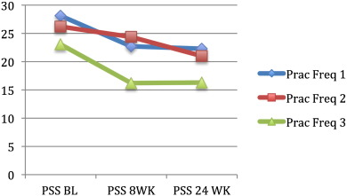

1. [Download: Download high-res image (112KB)](https://ars.els-cdn.com/content/image/1-s2.0-S0260691716000642-gr2_lrg.jpg)
2. [Download: Download full-size image](https://ars.els-cdn.com/content/image/1-s2.0-S0260691716000642-gr2.jpg)

Fig. 2. Graph depicting decreasing stress with practice frequency.

Prac Freq 1 = monthly, 2 = several times a month, 3 = weekly to daily practice.

### Mood

Mood was measured by the HADS and data was collected and evaluated for subscales of both anxiety and depression at each of the three time points. The mean HADS for anxiety did estimate a statistical significance at repeated time points following the mindfulness intervention (F(2,24) = 5.526, p = .011); however, tests of sphericity indicated that the sample size was not sufficient to accurately make this estimation. An effect size of .277 for anxiety indicated a mild to moderate effect of the intervention on anxiety. Decreasing means for anxiety between baseline and 24 weeks demonstrated that the intervention was generally effective in reducing anxiety, and thus, positively influencing mood (Table 2). The mean HADS for depression did not report a statistical significance at repeated time points (F(2,24) = .144, p = .867). The subscale of depression did not change, most likely due to the fact that the participant's mean pre HADS depression scale was already in the normal range with no indication of depression.

Table 2. Mood [Descriptive Statistics](https://www.sciencedirect.com/topics/social-sciences/descriptive-statistics) Based on HADS*.*

| Empty Cell | Mean | SD | N |
| --- | --- | --- | --- |
| Anxiety Baseline | 9 | 4.508 | 26 |
| Anxiety 8 weeks | 6.50 | 3.691 | 26 |
| Anxiety 24 weeks | 6.27 | 3.726 | 26 |
| Depression Baseline | 3.92 | 3.346 | 26 |
| Depression 8 weeks | 4.19 | 4.040 | 26 |
| Depression 24 weeks | 3.96 | 3.231 | 26 |

SD = standard deviation, N = number of participants.

A repeated measures [ANOVA](https://www.sciencedirect.com/topics/psychology/analysis-of-variance) with a Green-house Geisser correction determined that mean HADS (Anxiety) concentration differed statistically significantly between time points (F(1,23) = 6.889, p = .015) when practice frequency occurred on a weekly to daily basis. [Post hoc tests](https://www.sciencedirect.com/topics/nursing-and-health-professions/post-hoc-analysis) using the Bonferroni correction revealed that the mindfulness intervention elicited a slight reduction in anxiety levels specifically between practice frequency of less than once a month and weekly practice, which was statistically significant (p = .045). However, there was no significance between monthly and less than once a month (p = 0.129). See Fig. 3. Therefore, it is suggested that a weekly mindfulness intervention (practice frequency of once a week or greater) elicits a statistically significant reduction in anxiety, but only when used on regular weekly basis.

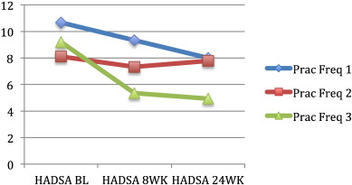

1. [Download: Download high-res image (115KB)](https://ars.els-cdn.com/content/image/1-s2.0-S0260691716000642-gr3_lrg.jpg)
2. [Download: Download full-size image](https://ars.els-cdn.com/content/image/1-s2.0-S0260691716000642-gr3.jpg)

Fig. 3. Graph depicting decreasing anxiety with practice frequency.

Prac Freq 1 = monthly, 2 = several times a month, 3 = weekly to daily practice.

HADSA = [HADS](https://www.sciencedirect.com/topics/nursing-and-health-professions/hospital-anxiety-and-depression-scale) anxiety score, BL = baseline.

### Cognition

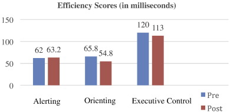

1. [Download: Download high-res image (97KB)](https://ars.els-cdn.com/content/image/1-s2.0-S0260691716000642-gr4_lrg.jpg)
2. [Download: Download full-size image](https://ars.els-cdn.com/content/image/1-s2.0-S0260691716000642-gr4.jpg)

Fig. 4. Graph depicting baseline (pre) and 8 week (post) ANT scores (n = 23). Decreasing scores demonstrate improvement in cognition efficiency.

Also there were improvements in accuracy across all conditions. There was a noticeably large improvement in the incongruent condition presented having to do with executive control following the completion of the eight week intervention. This improvement demonstrates an increased ability to focus attention among conflicting information.

## Discussion

Similar to other studies (Kang et al., 2009, Song and Lindquist, 2015, Ratanasiripong et al., 2015), findings from this study demonstrated that the eight week MBSR program offered to online nursing students appeared to be successful in decreasing stress at the end of the eight week program as well as retaining the lower stress levels at 24 weeks. Results also suggested that stress may have decreased as a result of more frequent practice meaning that the more the participant practiced the mindfulness strategies, the greater the stress reduction. Although statistical significance was not appreciated for anxiety across time points, the findings of the evidence of decreasing means could be a preliminary indicator that the program could also be effective for decreasing anxiety at the end of the eight week program as found in recent studies (Moriconi and Stabler-Haas, 2012, Song and Lindquist, 2015, Ratanasiripong et al., 2015), as well as retention of the benefit through the 24 week period. Like stress, anxiety appeared to have decreased as a result of increased practice of mindfulness interventions. As expected, since there were no scores depicting depression at baseline, rates of depression remained stable throughout.

Changes in participant cognition did not offer significant results; however, both the function of orienting and executive control demonstrated a decrease in response time means. Decreased values in these categories indicate improved efficiency. Also accuracy rates improved in every condition. There was a noticeably large improvement in the incongruent condition on the ANT involving the executive control function following the completion of the eight week program. This finding could suggest an increased ability to focus attention among conflicting or competing demands with quick and accurate responses. These findings may suggest the cognitive ability to increase efficiency and improve accuracy with MBSR training and practice.

Another positive outcome from the study was the recognized benefit of using the university's learning management system (LMS). The LMS was easy to use for the students since they log onto the university website frequently. Students could access the asynchronous intervention whenever it was convenient for them. No additional training was needed for either students or investigators. It was also free to use since it was part of the university portal. Whether programs are offered online or not, most universities and schools of nursing are relying on software to manage and organize courses. This software can serve as an ideal medium in which to push out non-course related information and interventions to online students.

Given the exploratory, novel nature of this initial investigation of an online MBSR program offered through a university learning management system, there are many limitations for this preliminary study resulting in the need for further, more controlled investigations. Although a sample of size of 50 would have been more desirable, only 26 nursing students consented to be in the study. There are several reasons that could have caused this. While participants were recruited from all nursing programs, the total number of active nursing students at any given time offers a pool of applicants less than 250. The programs are relatively short in length and that precluded students of each program in their final semester from participating. There would have been varying demands from work, home, and academic program prohibiting student commitment. There could have also been varying levels of comfort level with the LMS so the idea of doing an all online intervention might have been intimidating to those that were new to online learning or not as comfortable with the format.

Other limitations involved the inclusion/exclusion criteria and assessment of student characteristics. Anticipating possible difficulty with recruitment, our inclusion criteria were very broad by design in order to get a larger sample. Preexisting conditions or life situations affecting stress, mood or cognition were not widely explored, and current attitudes toward online learning, or technology skills could have also influenced results. Enrollment status was also not considered as it could be assumed that part-time students experienced less stress and anxiety than full-time students. It could also be expected that stress and anxiety levels were higher at the start of the program, and that as students progressed through the curriculum and became more familiar with the processes, stress and anxiety would decrease. Since students were not in a controlled environment but rather off campus while completing the online surveys, it was not known when the measures were being completed. Completing the measures at the end of a busy, hectic workday, while juggling family and school responsibilities, could have also influenced results.

Future projects involving mindfulness-based interventions should have a larger sample size in order to demonstrate that the intervention had an effect on the [dependent variables](https://www.sciencedirect.com/topics/nursing-and-health-professions/dependent-variable). A control group could strengthen the findings and more clearly describe the effectiveness on stress, mood and cognition. As several critical limitations were noted above, methodology maintaining closer control of student characteristics, including preexisting conditions, present life stressors, program enrollment status, program progression resulting in increased comfort levels, and personal situation while completing the measures, should be employed.

Several potential recommendations for educators surfaced as a result of the study. In an effort to mitigate stress, minimize anxiety, and improve cognition in online nursing students, faculty should first acknowledge that detrimental effects could possibly result from juggling multiple roles while enrolled in school. It is not unlikely that students returning to school may experience some stress, mood or cognition alterations that could impact their [academic performance](https://www.sciencedirect.com/topics/social-sciences/academic-performance). Not all students adapt well to the online environment and often do not understand the individualized, independent nature of the required learning activities. Some possible strategies for faculty to implement include: modeling healthy behaviors for completing every day workload and managing stress, educating students on and encouraging them to incorporate the behaviors found in the MBSR program into their daily lives, understanding students' unique situations and requests, and promoting a balance between work, home life and school in the online classroom. Orientation to the online learning environment and the skills, knowledge and attitudes needed to be successful in the online learning environment should also be shared prior to program start.

## Conclusion

Many nurses are finding themselves back in school to continue their education. Often times they elect to go to an online program because of the flexibility it offers. Many of these students are juggling multiple roles and may experience stress, changes in mood, or decreased cognition ultimately affecting their academic performance. Mindfulness-based stressed reduction has been studied as a means to mitigate untoward effects of life stressors. Offering an online mindfulness-based stress reduction program in the university learning management system was an easy, convenient, and accessible avenue in which to offer an intervention intended to mitigate stress, increase mood, and improve cognition. While the limitations of this initial investigation to this novel approach were clearly evident, the delivery of the intervention was successful and offered interesting results that warrant further exploration. Based on the results found, the intervention could have potentially been effective in mitigating stress and anxiety, and increasing cognition in a group of online, nursing students. Further studies, particularly with a larger sample size, clearer exploration of student characteristics related to the outcome variables, and a control group are needed to better demonstrate the significance of mindfulness- based interventions. With the growth of online nursing programs and the number of nurses going back to school, educators are challenged with optimizing [student performance](https://www.sciencedirect.com/topics/social-sciences/student-performance), growing enrollment, and increasing retention. Online stress reduction programs such as this one may be a strategy that will promote these efforts.

## References

1. Adorno, 2010

   M. Adorno

   A phenomenological study to describe the pursuit of a baccalaureate degree in nursing by associate degree registered nurses

   University of New Orleans (2010)

   (Theses and Dissertations, Paper 105)

   Google Scholar
2. Astin, 1997

   J.A. Astin

   Stress reduction through mindfulness meditation: effects on psychological, symptomatology, sense of control, and spiritual experiences

   Psychother. Psychosom., 66 (1997), pp. 97-106

   View at publisher

   [Crossref](https://doi.org/10.1159/000289116)[View in Scopus](https://www.scopus.com/inward/record.url?eid=2-s2.0-0030936907&partnerID=10&rel=R3.0.0)Google Scholar
3. Barnes et al., 2007

   S. Barnes, K.W. Brown, E. Krusemark, W.K. Campbell, R.D. Rogge

   The role of mindfulness in romantic relationship satisfaction and responses to relationship stress

   J. Marital. Fam. Ther., 33 (4) (2007), pp. 482-500, 10.1111/j.1752-0606.2007.00033.x

   View at publisher

   [View in Scopus](https://www.scopus.com/inward/record.url?eid=2-s2.0-34748833807&partnerID=10&rel=R3.0.0)Google Scholar
4. Beck et al., 1997

   D.L. Beck, M.B. Hackett, R. Srivastava, E. McKim, B. Rockwell

   Perceived level and source of stress in university professional schools

   J. Nurs. Educ., 36 (4) (1997), pp. 180-186

   [View at publisher](https://doi.org/10.3928/0148-4834-19970401-08)[Crossref](https://doi.org/10.3928/0148-4834-19970401-08)[View in Scopus](https://www.scopus.com/inward/record.url?eid=2-s2.0-0031115941&partnerID=10&rel=R3.0.0)Google Scholar
5. Beddoe and Murphy, 2004

   A.E. Beddoe, S.O. Murphy

   Does mindfulness decrease stress and foster empathy among nursing students?

   J. Nurs. Educ., 43 (7) (2004), pp. 305-312

   [View at publisher](https://doi.org/10.3928/01484834-20040701-07)[Crossref](https://doi.org/10.3928/01484834-20040701-07)[View in Scopus](https://www.scopus.com/inward/record.url?eid=2-s2.0-4444279409&partnerID=10&rel=R3.0.0)[Google Scholar](https://scholar.google.com/scholar_lookup?title=Does%20mindfulness%20decrease%20stress%20and%20foster%20empathy%20among%20nursing%20students&publication_year=2004&author=A.E.%20Beddoe&author=S.O.%20Murphy)
6. Bjelland et al., 2002

   I. Bjelland, A.A. Dahl, D. Heckelmann

   The validity of the hospital anxiety and depression scale: An updated literature review

   J. Psychosom. Res., 52 (2) (2002), pp. 69-77, 10.1016/s0022-3999(01)00296-3

   [View PDF](https://www.sciencedirect.com/science/article/pii/S0022399901002963/pdfft?md5=e2f9fdf3613b13cd9a9699d82a47b63a&pid=1-s2.0-S0022399901002963-main.pdf)[View article](https://www.sciencedirect.com/science/article/pii/S0022399901002963)Google Scholar
7. Brown and Ryan, 2003

   K.W. Brown, R.M. Ryan

   The benefits of being present: mindfulness and its role in psychological well-being. [research support, non-U.S. Gov't research support, U.S. Gov't, P.H.S. Validation studies]

   J. Pers. Soc. Psychol., 84 (4) (2003), pp. 822-848, 10.1037/0022-3514.84.4.822

   [View at publisher](https://doi.org/10.1037/0022-3514.84.4.822)[View in Scopus](https://www.scopus.com/inward/record.url?eid=2-s2.0-0038673754&partnerID=10&rel=R3.0.0)Google Scholar
8. Cohen and Janicki-Deverts, 2012

   S. Cohen, D. Janicki-Deverts

   Who's stressed? Distributions of psychological stress in the United States in probability samples from 1983, 2006 and 2009

   J. Appl. Soc. Psychol., 42 (2012), pp. 1320-1334

   View at publisher

   [Crossref](https://doi.org/10.1111/j.1559-1816.2012.00900.x)[View in Scopus](https://www.scopus.com/inward/record.url?eid=2-s2.0-84862202394&partnerID=10&rel=R3.0.0)Google Scholar
9. Cohen and Williamson, 1988

   S. Cohen, G.M. Williamson

   Perceived Stress in a Probability Sample of the United States

   S. Spacapan, S. Oskamp (Eds.), The Social Psychology of Health, Sage Publications, Newbury Park, CA (1988)

   [Google Scholar](https://scholar.google.com/scholar_lookup?title=Perceived%20Stress%20in%20a%20Probability%20Sample%20of%20the%20United%20States&publication_year=1988&author=S.%20Cohen&author=G.M.%20Williamson)
10. Cohen et al., 1983

    S. Cohen, T. Karmarck, R. Mermelstein

    A global measure of perceived stress

    J. Soc. Behav., 24 (1983), pp. 385-396, 10.2307/2136404

    [View at publisher](https://doi.org/10.2307/2136404)[View in Scopus](https://www.scopus.com/inward/record.url?eid=2-s2.0-0021009803&partnerID=10&rel=R3.0.0)[Google Scholar](https://scholar.google.com/scholar_lookup?title=A%20global%20measure%20of%20perceived%20stress&publication_year=1983&author=S.%20Cohen&author=T.%20Karmarck&author=R.%20Mermelstein)
11. Critz and Feagai, 2014

    C.M. Critz, H.E. Feagai

    Something's got to give: A description of contemporary nursing students

    Open J. Nurs., 4 (2014), pp. 123-131, 10.4236/oin.2014.43016

    [View at publisher](https://doi.org/10.4236/ojn.2014.43016)[Google Scholar](https://scholar.google.com/scholar_lookup?title=Somethings%20got%20to%20give%3A%20A%20description%20of%20contemporary%20nursing%20students&publication_year=2014&author=C.M.%20Critz&author=H.E.%20Feagai)
12. Davidson et al., 2003

    R.J. Davidson, J. Kabat-Zinn, J. Schmacher, M. Rosenkranz, D. Muller, S.F. Santorelli, F. Urbanowski, J.F. Sheridan

    Alterations in brain and immune function produced by mindfulness meditation

    Psychosom. Med., 65 (2003), pp. 564-570, 10.1097/01.PSY.0000077505.67574.E3

    (2003)

    [View at publisher](https://doi.org/10.1097/01.PSY.0000077505.67574.E3)[View in Scopus](https://www.scopus.com/inward/record.url?eid=2-s2.0-12444277335&partnerID=10&rel=R3.0.0)Google Scholar
13. Duffy et al., 2014

    M.T. Duffy, M.A. Friesen, K.G. Speroni, D. Swengros, L.A. Shanks, P.A. Waiter, M.J. Sheridan

    BSN completion barriers, challenges, incentives, and strategies

    J. Nurs. Adm., 44 (4) (2014), pp. 232-236

    [View in Scopus](https://www.scopus.com/inward/record.url?eid=2-s2.0-84896937773&partnerID=10&rel=R3.0.0)Google Scholar
14. Evans et al., 2008

    S. Evans, S. Ferrando, M. Findler, C. Stowell, C. Smart, D. Haglin

    Mindfulness-based cognitive therapy for generalized anxiety disorder

    J. Anxiety Disord., 22 (4) (2008), pp. 716-721, 10.1016/j.janxdis.2007.07.005

    [View PDF](https://www.sciencedirect.com/science/article/pii/S0887618507001569/pdfft?md5=88dffd91d78713f1793b8fa2d0f535d9&pid=1-s2.0-S0887618507001569-main.pdf)[View article](https://www.sciencedirect.com/science/article/pii/S0887618507001569)[View in Scopus](https://www.scopus.com/inward/record.url?eid=2-s2.0-41549168077&partnerID=10&rel=R3.0.0)Google Scholar
15. Fan et al., 2002

    J. Fan, B.D. McCandliss, T. Sommer, M. Raz, M.I. Posner

    Testing the efficiency and independence of attentional networks

    J. Cogn. Neurosci., 14 (2002), pp. 340-347, 10.1162/089892902317361886

    [View at publisher](https://doi.org/10.1162/089892902317361886)Google Scholar
16. Grossman et al., 2004

    P. Grossman, L. Niemann, S. Schmidt, H. Walach

    Mindfulness-based stress reduction and health benefits. A Meta-analysis

    J. Psychosom. Res., 57 (1) (2004), pp. 35-43, 10.1016/S0022-3999(03)00573-7

    [View PDF](https://www.sciencedirect.com/science/article/pii/S0022399903005737/pdfft?md5=d37d5870d3beff3db522c26014a892a2&pid=1-s2.0-S0022399903005737-main.pdf)[View article](https://www.sciencedirect.com/science/article/pii/S0022399903005737)[View in Scopus](https://www.scopus.com/inward/record.url?eid=2-s2.0-3142646773&partnerID=10&rel=R3.0.0)Google Scholar
17. Harris and Burman, 2015

    P.W. Harris, M.E. Burman

    Nurses returning to school: Motivators, inhibitors and job satisfaction

    J. Prof. Nurs., 0 (2015), pp. 1-9, 10.1016/jprofnurs.2015.10.008

    [View at publisher](https://doi.org/10.1016/jprofnurs.2015.10.008)[View in Scopus](https://www.scopus.com/inward/record.url?eid=2-s2.0-84923923958&partnerID=10&rel=R3.0.0)[Google Scholar](https://scholar.google.com/scholar_lookup?title=Nurses%20returning%20to%20school%3A%20Motivators%2C%20inhibitors%20and%20job%20satisfaction&publication_year=2015&author=P.W.%20Harris&author=M.E.%20Burman)
18. IOM (Institute of Medicine), 2011

    IOM (Institute of Medicine)

    The Future of Nursing: Leading Change

    Advancing Health, The National Academies Press, Washington, DC (2011)

    Google Scholar
19. Jha et al., 2007

    A. Jha, J. Krompinger, M.J. Baime

    Mindfulness training modifies subsystems of attention

    Cogn. Affect. Behav. Neurosci., 7 (2007), pp. 109-119, 10.3758/CABN.7.2.109

    View at publisher

    [View in Scopus](https://www.scopus.com/inward/record.url?eid=2-s2.0-34250821721&partnerID=10&rel=R3.0.0)[Google Scholar](https://scholar.google.com/scholar_lookup?title=Mindfulness%20training%20modifies%20subsystems%20of%20attention&publication_year=2007&author=A.%20Jha&author=J.%20Krompinger&author=M.J.%20Baime)
20. Kabat-Zinn, 1996

    J. Kabat-Zinn

    Mindfulness Meditation: What it Is, what it isn't, and its Role in Health Care and Medicine

    J. Haryuki, Y. Ishii, M. Suzuki (Eds.), Comparative and Psychological Study on Meditation, Eburon Academic Publishers, Netherlands (1996), pp. 161-170

    Google Scholar
21. Kabat-Zinn, 2005

    J. Kabat-Zinn

    Coming to our Senses: Healing Ourselves and the World through Mindfulness

    Hyperion, New York (2005)

    [Google Scholar](https://scholar.google.com/scholar_lookup?title=Coming%20to%20our%20Senses%3A%20Healing%20Ourselves%20and%20the%20World%20through%20Mindfulness&publication_year=2005&author=J.%20Kabat-Zinn)
22. Kabat-Zinn, 2013

    J. Kabat-Zinn

    Full Catastrophe Living: Using the Wisdom of your Body and Mind to Face Stress, Pain, and Illness (Revised Ed)

    Bantam Dell, New York, NY (2013)

    Google Scholar
23. Kang et al., 2009

    Y.S. Kang, S.Y. Choi, E. Ryu

    The effectiveness of a stress coping program based on mindfulness meditation on the stress, anxiety, and depression experienced by nursing students in Korea

    Nurse Educ. Today, 29 (2009), pp. 538-543, 10.1037/1931-3918.1.2.105

    [View PDF](https://www.sciencedirect.com/science/article/pii/S0260691708001792/pdfft?md5=d925454f422483a1e1fabc7f35407ea7&pid=1-s2.0-S0260691708001792-main.pdf)[View article](https://www.sciencedirect.com/science/article/pii/S0260691708001792)[View in Scopus](https://www.scopus.com/inward/record.url?eid=2-s2.0-67349145699&partnerID=10&rel=R3.0.0)Google Scholar
24. Kovner et al., 2012

    C.T. Kovner, C. Brewer, C. Katigbak, M. Djukic, F. Fatehi

    Charting the course for nurses' achievement of higher education levels

    J. Prof. Nurs., 28 (6) (2012), pp. 333-343

    [View PDF](https://www.sciencedirect.com/science/article/pii/S8755722312000774/pdfft?md5=c6e415b4a3a5364667b640decdf96c8d&pid=1-s2.0-S8755722312000774-main.pdf)[View article](https://www.sciencedirect.com/science/article/pii/S8755722312000774)[View in Scopus](https://www.scopus.com/inward/record.url?eid=2-s2.0-84869833784&partnerID=10&rel=R3.0.0)Google Scholar
25. Moriconi and Stabler-Haas, 2012

    C. Moriconi, S. Stabler-Haas

    Mindfulness-based stress reduction (MBSR), and its effect on test anxiety and focused attention with baccalaureate nursing students. [Abstract]

    Presentation at Fifth Annual Mindfulness in Education Network Conference: Mindfulness: Foundation for Teaching and Learning, Bryn Mawr College, Bryn Mawr, PA (2012)

    (March 16–18, 2012)

    Google Scholar
26. National Center for Complementary and Alternative Medicine,

    National Center for Complementary and Alternative Medicine

    Meditation: An Introduction - NIH Intro to Meditation

    (2010)

    (Retrieved from)

    https://nccih.nih.gov/sites/nccam.nih.gov/files/meditation.pdf

    Google Scholar
27. Patient Protection and Affordable Health Care Act, 2010

    Patient Protection and Affordable Health Care Act

    Public law 111–148

    congressional record, vol. 156 (2010)

    (Retrieved from http://www.gpo.gov/fdsys/pkg/PLAW-111publ148/pdf/PLAW-111publ148.pdf)

    [Google Scholar](https://scholar.google.com/scholar_lookup?title=Public%20law%20111148&publication_year=2010&author=Patient%20Protection%20and%20Affordable%20Health%20Care%20Act)
28. Pryjmachuk and Richards, 2007

    S. Pryjmachuk, D.A. Richards

    Predicting Stress in Pre-Registration Nursing Students

    Br. J. Health Psychol., 12 (1) (2007), pp. 125-144

    [View in Scopus](https://www.scopus.com/inward/record.url?eid=2-s2.0-33846840498&partnerID=10&rel=R3.0.0)[Google Scholar](https://scholar.google.com/scholar_lookup?title=Predicting%20Stress%20in%20Pre-Registration%20Nursing%20Students&publication_year=2007&author=S.%20Pryjmachuk&author=D.A.%20Richards)
29. Ratanasiripong et al., 2015

    P. Ratanasiripong, J.F. Park, N. Ratanasiripong, D. Kathalae

    Stress and anxiety management in nursing students: biofeedback and mindfulness meditation

    J. Nurs. Educ., 54 (2015), pp. 520-524, 10.3928/01484834-20150814-07

    [View at publisher](https://doi.org/10.3928/01484834-20150814-07)[View in Scopus](https://www.scopus.com/inward/record.url?eid=2-s2.0-84946921025&partnerID=10&rel=R3.0.0)Google Scholar
30. Reibel et al., 2001

    D.K. Reibel, J.M. Greeson, G.C. Brainard, S. Rosenzweig

    Mindfulness-based stress reduction and health-related quality of life in a heterogeneous patient population

    Gen. Hosp. Psychiatry, 23 (2001), pp. 183-192

    [View PDF](https://www.sciencedirect.com/science/article/pii/S0163834301001499/pdfft?md5=b3584df6184b4883dfef39c967e58caf&pid=1-s2.0-S0163834301001499-main.pdf)[View article](https://www.sciencedirect.com/science/article/pii/S0163834301001499)[View in Scopus](https://www.scopus.com/inward/record.url?eid=2-s2.0-0034864119&partnerID=10&rel=R3.0.0)Google Scholar
31. Rosenzweig et al., 2003

    S. Rosenzweig, D.K. Reibel, J.M. Greeson, G.C. Brainard, M. Hojat

    Mindfulness-based stress reduction lowers psychological distress in medical students

    Teach. Learn. Med., 15 (2) (2003), pp. 88-92, 10.1207/S15328015TLM1502_03

    View at publisher

    [View in Scopus](https://www.scopus.com/inward/record.url?eid=2-s2.0-0042278699&partnerID=10&rel=R3.0.0)Google Scholar
32. Shapiro and Schwartz, 2000

    S.L. Shapiro, G.E. Schwartz

    The Role of Intention in Self-Regulation: Toward Intentional Systemic Mindfulness

    M. Boekaeerts, P.R. Pintrich, M. Zeidner (Eds.), Handbook of Self-Regulation, Academic Press, San Diego (2000), pp. 253-273

    [View PDF](https://www.sciencedirect.com/science/article/pii/B9780121098902500378/pdfft?md5=98504a533f70a98002a65a18406e30a1&pid=3-s2.0-B9780121098902500378-main.pdf)[View article](https://www.sciencedirect.com/science/article/pii/B9780121098902500378)Google Scholar
33. Shapiro et al., 2006

    S.L. Shapiro, L.E. Carlson, J.A. Astin, B. Freedman

    Mechanisms of mindfulness

    J. Clin. Psychol., 62 (3) (2006), pp. 373-386, 10.1002/jclp.20237

    View at publisher

    [View in Scopus](https://www.scopus.com/inward/record.url?eid=2-s2.0-33645100573&partnerID=10&rel=R3.0.0)[Google Scholar](https://scholar.google.com/scholar_lookup?title=Mechanisms%20of%20mindfulness&publication_year=2006&author=S.L.%20Shapiro&author=L.E.%20Carlson&author=J.A.%20Astin&author=B.%20Freedman)
34. Shapiro et al., 2007

    S.L. Shapiro, K. Brown, G. Biegel

    Self-care for health care professionals: Effects of MBSR on mental well being of counseling psychology students

    Train. Educ. Prof. Psychol., 1 (2007), pp. 105-115, [10.1037/1931–3918.1.2.105](https://doi.org/10.1037/1931%E2%80%933918.1.2.105)

    [View at publisher](https://doi.org/10.1037/1931-3918.1.2.105)[View in Scopus](https://www.scopus.com/inward/record.url?eid=2-s2.0-34249824632&partnerID=10&rel=R3.0.0)Google Scholar
35. Shapiro et al., 2008

    S.L. Shapiro, K. Brown, J.A. Astin

    Toward the integration of meditation into higher education: A review of research evidence

    Teach. Coll. Rec., 113 (2008), pp. 493-528

    Google Scholar
36. Sharma and Rush, 2014

    M. Sharma, S.E. Rush

    Mindfulness-based stress reduction as a stress management intervention for healthy individuals: A systematic review

    J. Evid. Based Complement. Altern. Med., 19 (4) (2014), pp. 271-286

    View at publisher

    [Crossref](https://doi.org/10.1177/2156587214543143)[View in Scopus](https://www.scopus.com/inward/record.url?eid=2-s2.0-84907217924&partnerID=10&rel=R3.0.0)Google Scholar
37. Snaith, 2003

    R.P. Snaith

    The hospital anxiety and depression scale

    Health Qual. Life Outcomes, 1 (14) (2003), [10.1186/1477–7525-1-29](https://doi.org/10.1186/1477%E2%80%937525-1-29)

    (Retrieved from http://link.springer.com/article/10.1186/1477-7525-1-29/fulltext.html)

    [View at publisher](https://doi.org/10.1186/1477%E2%80%937525-1-29)[Google Scholar](https://scholar.google.com/scholar_lookup?title=The%20hospital%20anxiety%20and%20depression%20scale&publication_year=2003&author=R.P.%20Snaith)
38. Song and Lindquist, 2015

    Y. Song, R. Lindquist

    Effects of mindfulness-based stress reduction on depression, anxiety, stress and mindfulness in Korean nursing students

    Nurse Educ. Today, 35 (2015), pp. 86-90, 10.1016/j.nedt.2014.06.010

    [View PDF](https://www.sciencedirect.com/science/article/pii/S0260691714002226/pdfft?md5=82cb6e099a858ca6cf4fe807b8fc80f1&pid=1-s2.0-S0260691714002226-main.pdf)[View article](https://www.sciencedirect.com/science/article/pii/S0260691714002226)[View in Scopus](https://www.scopus.com/inward/record.url?eid=2-s2.0-84919391441&partnerID=10&rel=R3.0.0)Google Scholar
39. Spagna et al., 2015

    A. Spagna, M.A. Mackie, J. Fan

    Supramodal Executive Control of Attention

    Front. Psychol., 6 (2015), 10.3389/fpsyg.2015.00065

    (Retrieved from https://www.researchgate.net/publication/272739952_Supramodal_executive_control_of_attention)

    [View at publisher](https://doi.org/10.3389/fpsyg.2015.00065)[Google Scholar](https://scholar.google.com/scholar_lookup?title=Supramodal%20Executive%20Control%20of%20Attention&publication_year=2015&author=A.%20Spagna&author=M.A.%20Mackie&author=J.%20Fan)
40. Teasdale, 1999

    J.D. Teasdale

    Metacognition, mindfulness and the modification of mood disorders

    Clin. Psychol. Psychother., 6 (1999), pp. 146-155, 10.1002/(SICI)1099-0879(199905)6:2<146::AID-CPP195>3.0.CO;2-E

    View at publisher

    [View in Scopus](https://www.scopus.com/inward/record.url?eid=2-s2.0-0000622029&partnerID=10&rel=R3.0.0)[Google Scholar](https://scholar.google.com/scholar_lookup?title=Metacognition%2C%20mindfulness%20and%20the%20modification%20of%20mood%20disorders&publication_year=1999&author=J.D.%20Teasdale)
41. van der Riet et al., 2015

    P. van der Riet, R. Rossiter, D. Kirby, T. Dluzewska, C. Harmon

    Piloting a stress management and mindfulness program for undergraduate nursing students: Study feedback and lessons learned

    Nurse Educ. Today, 35 (2015), pp. 44-49, 10.1016/j.nedt.2014.05.003

    [View PDF](https://www.sciencedirect.com/science/article/pii/S0260691714001877/pdfft?md5=9ba66a7c6d4b2798eb058f7f3d3c86eb&pid=1-s2.0-S0260691714001877-main.pdf)[View article](https://www.sciencedirect.com/science/article/pii/S0260691714001877)[View in Scopus](https://www.scopus.com/inward/record.url?eid=2-s2.0-84919386906&partnerID=10&rel=R3.0.0)Google Scholar
42. Zigmond and Snaith, 1983

    A.S. Zigmond, R.P. Snaith

    The hospital anxiety and depression scale

    Acta Psychiatr. Scand., 67 (6) (1983), pp. 361-370, 10.1111/j.1600-0447

    View at publisher

    [View in Scopus](https://www.scopus.com/inward/record.url?eid=2-s2.0-0020527558&partnerID=10&rel=R3.0.0)[Google Scholar](https://scholar.google.com/scholar_lookup?title=The%20hospital%20anxiety%20and%20depression%20scale&publication_year=1983&author=A.S.%20Zigmond&author=R.P.%20Snaith)

## Cited by (89)

### [The future of mindfulness training is digital, and the future is now](https://www.sciencedirect.com/science/article/pii/S2352250X18301945)

- 2019, Current Opinion in Psychology

  Citation Excerpt :

  Meta-analysis of the eight studies found a significant medium effect size for the mindfulness interventions on perceived stress. Further research utilizing a variety of d-MBIs and participant populations has provided additional support for the efficacy of d-MBIs in reducing stress [24–28]. However, failures to replicate this stress effect have occurred [29,30].

### [Brief, daily meditation enhances attention, memory, mood, and emotional regulation in non-experienced meditators](https://www.sciencedirect.com/science/article/pii/S016643281830322X)

- 2019, Behavioural Brain Research

### [The effectiveness of mindfulness meditation for nurses and nursing students: An integrated literature review](https://www.sciencedirect.com/science/article/pii/S0260691718301436)

- 2018, Nurse Education Today

### [Mindfulness-based stress reduction and mindfulness-based cognitive therapy for psychological health and well-being in nonclinical samples: A systematic review and meta-analysis.](https://doi.org/10.1037/str0000165)

- 2020, International Journal of Stress Management

### [Digital mental health interventions for depression, anxiety and enhancement of psychological well-being among college students: Systematic review](https://doi.org/10.2196/12869)

- 2019, Journal of Medical Internet Research

### [The Effects of a Modified Mindfulness-Based Stress Reduction Program for Nurses: A Randomized Controlled Trial](https://doi.org/10.1177/2165079918801633)

- 2019, Workplace Health and Safety

**<sup>☆</sup>**

Acknowledgement/funding source: Chatham University Research And Sabbaticals Committee

[View Abstract](https://www.sciencedirect.com/science/article/abs/pii/S0260691716000642)

Copyright © 2016 Elsevier Ltd. All rights reserved.

  Shirlene Aparecida Lopes, …, Maria do Patrocínio Tenório Nunes

  [View PDF](https://www.sciencedirect.com/science/article/pii/S1524904217304216/pdfft?md5=5b8e0acc7028666195099d51a4a706ef&pid=1-s2.0-S1524904217304216-main.pdf)

  Y. Luo, …, W. Ge

  [View PDF](https://www.sciencedirect.com/science/article/pii/S0033350619301623/pdfft?md5=a108304e0f6a0cb7115458ad410cf381&pid=1-s2.0-S0033350619301623-main.pdf)

  Moira Walker, Robert A. Mann

  [View PDF](https://www.sciencedirect.com/science/article/pii/S0260691716001040/pdfft?md5=f0dae9599ebcccb71d55845af90438bd&pid=1-s2.0-S0260691716001040-main.pdf)

### Social Media

- Shares, Likes & Comments1

[View details](https://plu.mx/plum/a/?doi=10.1016%2Fj.nedt.2016.02.006&theme=plum-sciencedirect-theme&hideUsage=true)

Reference

  J. Nurs. Educ., 54 (2015), pp. 520-524, 10.3928/01484834-20150814-07

View in article